# deep_feedforward_networks slides

## Deep Feedforward Networks

```python
import numpy as np
import matplotlib.pyplot as plt

%matplotlib inline
```

#### Feedforward and XOR

El autor sugiere revisar el ejemplo XOR, donde hay 4 posibles escenarios, es decir:

$$ X = \left \{ [0, 0], [1, 0], [0, 1], [1, 1] \right \} $$

Entonces tenemos una funcion que es la verdadera $f^{*}$ y otra que es una aproximacion $f$, un intento por ser similar a la verdadera. Hay muchas formas de medir la diferencia o similitud entre ambas, un MSE loss esta dado de la siguiente forma:

$$ J(\theta) = \frac{1}{4}\sum^{}_{x \in X} \left [ f^*(x) - f(x; \theta) \right ]^2 $$

```python
# basicamente son dos funciones que pueden ser

def true_fn(x):
    return 'Im true'

def estimated_fn(x, theta):
    return 'Im trying to be true'
```

Si `true_fn` es lineal, seria muy facil lograr estimarla, simplemente buscando unos parametros $\theta$ que minimicen $J(\theta)$. Pero que pasa cuando no conocemos `true_fn`, y si es no lineal? Como se puede aproximar a esta funcion? Aqui es importante saber que $f(x; \theta)$ puede ser bastante compleja, teniendo varias funciones dentro de si misma, algo como $f(x; w, W) = f^2(f^1(x;w);W)$, es decir, $f$ tiene dos capas internas $f^1$ y $f^2$. Donde cada capa puede ser lineal o no lineal. Una solucion a el problema XOR esta dada por la siguiente funcion compuesta por dor funciones:

$$ f(x; W, c, w, b) = w^T max \left \{ 0, W^Tx + c \right \} + b $$

Notese que $\theta$ esta compuesto por los parametros $W, c, w, b$. Y aqui tenemos que la primera funcion es $h = f^1(x) = max \left \{ 0, W^Tx + c \right \}$ y la segunda es $f^2(h) = w^T h + b$. La funcion $max$ agrega no linealidad a nuestra ecuacion.

```python
# entonces la solucion al XOR estaria dada por lo siguiente

W = np.array(
    [
        [1, 1],
        [1, 1]
    ]
)
c = np.array([0, -1])
w = np.array([1, -2])
X = np.array([
    [0, 0],
    [0, 1],
    [1, 0],
    [1, 1]
])

XW_c= X@W + c
print('XW + c')
print(XW_c)
print('-----')

h = np.where(XW_c > 0 , XW_c, 0)
print('h')
print(h)
print('-----')

y = h@w # en este caso b = 0
print('y')
print(y) # este es el resultado correcto
```

```
XW + c
[[ 0 -1]
 [ 1  0]
 [ 1  0]
 [ 2  1]]
-----
h
[[0 0]
 [1 0]
 [1 0]
 [2 1]]
-----
y
[0 1 1 0]
```

#### Learning Conditional Distributions with Maximum Likelihood

El autor sostiene que muchas de las redes neuronales que hoy en dia se entrenan, hacen uso del Maximum Likelihood para estimar la similitud entre la verdadera distribucion y la distribucion del modelo. Consecuentemente se puede usar *cross entropy* para maximizar la verosimilitud:

$$ J(\theta) = -E_{X,Y \sim \hat{p_{data}}} \left \| log p_{model}(y | x) \right \| $$

Si se revisa la ecuacion para el *cross entropy* para datos discretos tenemos que:

$$ H(P,Q) = -\sum^{}_{x \in X} p(x) log q(x) $$

Entonces se puede plantear lo siguiente:

```python
# tenemos los datos sinteticos que provienen de la siguiente funcion verdadera
def true_fn(x):
    if (-1)**x < 0:
        return 0
    else:
        return 1
```

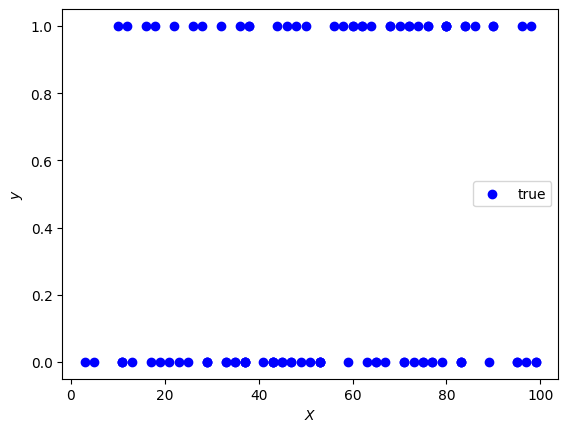

```python
# los valores de X
X = np.random.randint(1, 100, 100)
# los valores de y
y = np.array(list(map(true_fn, X)))
# la grafica
plt.scatter(X, y, color='blue', label='true')
plt.xlabel('$X$')
plt.ylabel('$y$')
plt.legend()
plt.show()
```

Claramente estamos ante una funcion no lineal (en la practica no sabemos cual es la funcion verdadera, sino que sentido tendria el Deep Learning).

```python
# definicion de una funcion que "intenta" aproximarse a la verdadera funcion
def estimated_fn(x):
    if x > 30:
        return 0.99
    else:
        return 0.01
```

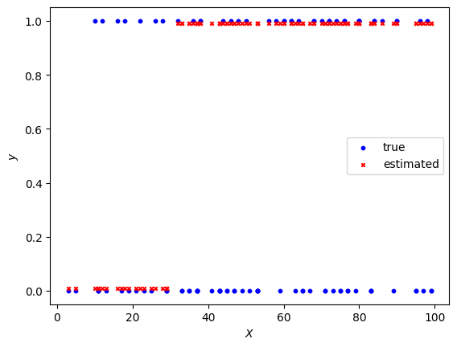

```python
# obtengo valores estimados
y_hat = np.array(list(map(estimated_fn, X)))
# grafica contra los valores verdaderos
plt.scatter(X, y, color='blue', label='true', s=10)
plt.scatter(X, y_hat, color='red', label='estimated', marker='x', s=10)
plt.xlabel('$X$')
plt.ylabel('$y$')
plt.legend()
plt.show()
```

```python
# y se puede obtener el cross entropy de la siguiente forma
def cross_entropy(y_true, y_estimated):
    return -np.sum(y_true*np.log(y_estimated))

print(cross_entropy(y, y_hat))
```

```
32.577902720935676
```

Cabe notar que los modelos estimados no pueden arrojar probabilidades estimadas de $0$ o $1$ porque tendriamos un problema a la hora de calcular el *cross entropy* (logaritmos de ceros y unos), por esta razon es que las funciones de activacion esta estructuradas para evitar este problema, por ejemplo la *logistic regression*.

Es muy importante entender el papel de los gradientes cuando un algoritmo debe aprender.

[figure not shown]

Cuando los gradientes son bajos se puede decir que el algoritmo aprende muy poco, un ejemplo de como puede pasar esto es con la funcion *sigmoid*, cuando el valor de $x$ en $f(x)$ (siendo $f$ una funcion sigmoid) es muy grande o muy bajo, los gradientes de la funcion seran bajos.

```python
def sigmoid(x):
    return 1 / (1 + np.exp(-x))


print('Un incremento del 100% partiendo desde x = 0 a x = 1:', sigmoid(0), '->' ,sigmoid(1))
print('Un incremento del 100% partiendo desde x = 10 a x = 20:', sigmoid(10), '->' ,sigmoid(20))
```

```
Un incremento del 100% partiendo desde x = 0 a x = 1: 0.5 -> 0.7310585786300049
Un incremento del 100% partiendo desde x = 10 a x = 20: 0.9999546021312976 -> 0.9999999979388463
```

Entonces, al tener un gradiente tan bajo, los cambios en los parametros producto de este gradiente seran muy bajos y por ende no habra mucho efecto en la funcion de costos. Al final el aprendizaje sera nulo o mas lento.

Segun el autor, la parte de la ecuacion $log q(x)$ ayuda a compensar el efecto que puede dar el `exp` en muchas funciones de activacion.

Por otro lado, cuando usamos el MSE o MAE no tenemos los beneficios que presenta el *cross entropy* y se puede caer facilmente en problemas de bajos gradientes. Por esto, es muy usual ver el *cross entropy* incluso cuando no es necesario estimar por completo $p(y|x)$.